# Understanding the interface to sortable.js

Andrie de Vries and Kenton Russell

2019-06-26

With `sortable` [`htmlwidget`](https://htmlwidgets.org) you can use powerful, dependency-free interactivity from [`Sortable.js`](https://sortablejs.github.io/Sortable/) in the browser, RStudio Viewer, or RStudio Shiny.

```r
library(sortable)
```

## The central idea

The key idea to understand about `sortable`, and `sortable.js` in particular, is that the JavaScript will manipulate an HTML object based on it’s CSS `id`.

Using `sortable` in markdown is a little tricky since markdown does not provide an easy way to provide an `id` that we’ll need. We can overcome this by using bare `HTML` or using `htmltools::tags`. Let’s make a simple `ul` list. Note, however, that `sortable` works with nearly any `HTML` element, such as `div`.

### An example using raw HTML

The following example uses HTML to construct an unordered list (`<ul>`), and then uses `sortable_js()` to link the JavaScript required to create interactivity.

Note:

1. The HTML `id` matches the `selector` argument of `sortable_js()`.
2. You can drag and drop the list entries. Try it!

```html
<p>You can drag and drop these items in any order:</p>
<ul id = "example01">
  <li>Move</li>
  <li>Or drag</li>
  <li>Each of the items</li>
  <li>To different positions</li>
</ul>
```

````r
```{r}
sortable_js(selector = "example01")
```
````

You can drag and drop these items in any order:

- Move
- Or drag
- Each of the items
- To different positions

[interactive chart not shown]

[figure not shown]

### Use a tag list to achieve the same, but from R

You can use the functions `tags()` and `tagList()`, both from the `htmltools` package, to create HTML.

```r
library(htmltools)
tagList(
  tags$ul(
    id = "example02",
    tags$li("drag me"),
    tags$li("sort me"),
    tags$li("any way you like")
  ),
  sortable_js("example02")
)
```

- drag me
- sort me
- any way you like

[interactive chart not shown]

### Little Harder but Better Example

The `sortable.js` functionality works with any HTML object, not just lists.

In this next example, you can see how to drag and drop images (`<img>`). To embed the plots on the page, you can use the `base64::img()` function to encode the png images into a format that HTML understands.

Again, notice that the HTML `id` matches the `selector`.

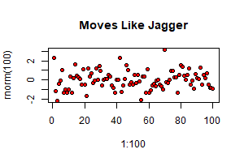

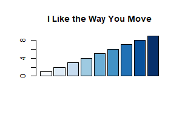

[interactive chart not shown]

```r
library(base64)
library(withr)

# use example from ?base64::img
pngfile_1 <- tempfile()
with_png(pngfile_1, width = 300, height = 200,{
  plot(1:100, rnorm(100), pch = 21, bg = "red")
  title(main = "Moves Like Jagger")
})

# make another plot for demo purposes
pngfile_2 <- tempfile()
with_png(pngfile_2, width = 300, height = 200,{
  barplot(1:9, col = blues9)
  title(main = "I Like the Way You Move")
})

tagList(
  tags$div(
    id = "example03",
    HTML(img(pngfile_1)),
    HTML(img(pngfile_2))
  ),
  sortable_js(selector = "example03")
)
```

## The power of groups

Looking at the [`Sortable.js`](https://github.com/SortableJS/Sortable#options) excites me about the potential to use `sortable` as an important UI element in both a Shiny and non-Shiny context. We could potentially demo a plot builder with something like this example. You’ll notice that it doesn’t really do anything, but I hope the intent and direction is clear.

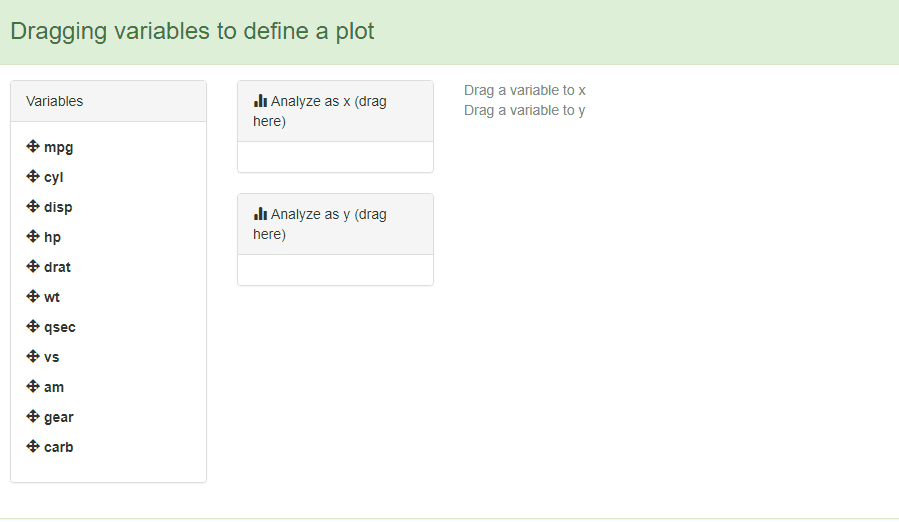

```r
knitr::read_chunk(
  systm.file("shiny-examples/drag_vars_to_plot_app.R", package = "sortable")
)
```

## Dragging and dropping shiny tabs

I learned late last night that `sortable` will allow movable tabs inside a Shiny (and also not Shiny) app. By adding just one line of code and an `id` to this RStudio [Tabset example](https://github.com/rstudio/shiny-examples/tree/master/006-tabsets), we get rearrangeable tabs. I really hope you’ll copy and paste to see it for yourself, or you can `runGist("2dbe45f77b65e28acab9")`.

The modified code snippet is:

```r
      # Show a tabset that includes a plot, summary, and table view
      # of the generated distribution
      mainPanel(
        tabsetPanel(
          type = "tabs",
          id = "sortTab",
          tabPanel("Plot", plotOutput("plot")),
          tabPanel("Summary", verbatimTextOutput("summary")),
          tabPanel("Table", tableOutput("table"))
        )
      )
    ),
    sortable_js("sortTab")
```

And the full code:

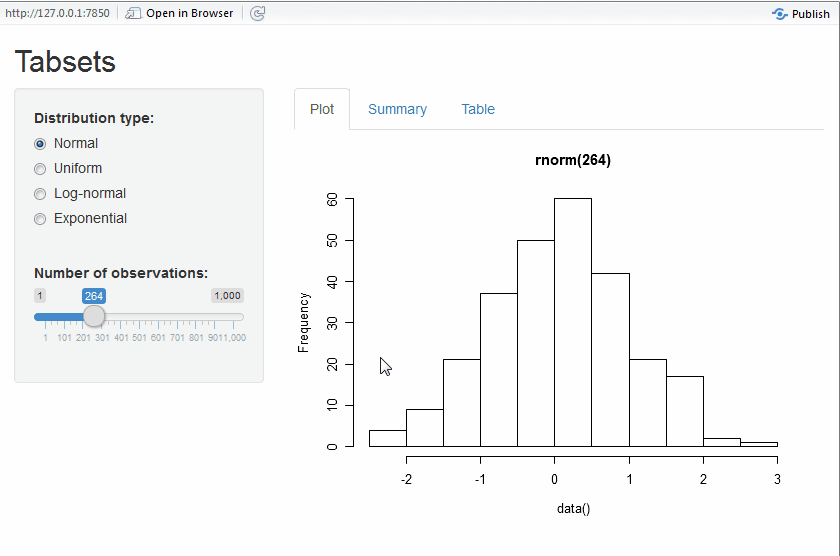

```r
## Example shiny app to create a plot from sortable inputs


# all credit for code goes to RStudio
# https://github.com/rstudio/shiny-examples/tree/master/006-tabsets
library(sortable)
library(shiny)

ui = # Define UI for random distribution application
  shinyUI(fluidPage(

    # Application title
    titlePanel("Tabsets"),

    # Sidebar with controls to select the random distribution type
    # and number of observations to generate. Note the use of the
    # br() element to introduce extra vertical spacing
    sidebarLayout(
      sidebarPanel(
        radioButtons(
          "dist", "Distribution type:",
          c(
            "Normal" = "norm",
            "Uniform" = "unif",
            "Log-normal" = "lnorm",
            "Exponential" = "exp"
          )
        ),
        br(),

        sliderInput(
          "n",
          "Number of observations:",
          value = 500,
          min = 1,
          max = 1000)
      ),

      # Show a tabset that includes a plot, summary, and table view
      # of the generated distribution
      mainPanel(
        tabsetPanel(
          type = "tabs",
          id = "sortTab",
          tabPanel("Plot", plotOutput("plot")),
          tabPanel("Summary", verbatimTextOutput("summary")),
          tabPanel("Table", tableOutput("table"))
        )
      )
    ),
    sortable_js("sortTab")
  ))

server = function(input, output) {

  # Reactive expression to generate the requested distribution.
  # This is called whenever the inputs change. The output
  # functions defined below then all use the value computed from
  # this expression
  data <- reactive({
    dist <- switch(
      input$dist,
      norm = rnorm,
      unif = runif,
      lnorm = rlnorm,
      exp = rexp,
      rnorm
    )

    dist(input$n)
  })

  # Generate a plot of the data. Also uses the inputs to build
  # the plot label. Note that the dependencies on both the inputs
  # and the data reactive expression are both tracked, and
  # all expressions are called in the sequence implied by the
  # dependency graph
  output$plot <- renderPlot({
    dist <- input$dist
    n <- input$n

    hist(data(),
         main=paste('r', dist, '(', n, ')', sep=''))
  })

  # Generate a summary of the data
  output$summary <- renderPrint({
    summary(data())
  })

  # Generate an HTML table view of the data
  output$table <- renderTable({
    data.frame(x = data())
  })

}

shinyApp( ui, server )
```